[figure not shown]

[figure not shown]

# Indlæsning af data

Vi betragter datasættet fra kompendiets Eksempel 3.2.

```r
ex32 <- read.table(file = "../data/Example32.txt", header = T)
head(ex32, 20)
```

```
        TREAT TIME organic
1  Ivermectin    8  3028.7
2  Ivermectin    8  2805.7
3  Ivermectin    8  3061.3
4  Ivermectin    8  3113.4
5  Ivermectin    8  2938.1
6  Ivermectin    8  3063.4
7  Ivermectin   12  2765.0
8  Ivermectin   12  2713.7
9  Ivermectin   12  2945.7
10 Ivermectin   12  2869.3
11 Ivermectin   12  2902.0
12 Ivermectin   12  2836.6
13 Ivermectin   16  2413.3
14 Ivermectin   16  2592.6
15 Ivermectin   16  2804.7
16 Ivermectin   16  2546.5
17 Ivermectin   16  2823.7
18 Ivermectin   16  2845.2
19    Control    8  2425.0
20    Control    8  2630.1
```

# Undersøg forsøgsdesign

Begge faktorerne **TREAT** og **TIME** er balancerede.

```r
table(ex32$TREAT)
```

```
   Control Ivermectin
        18         18
```

```r
table(ex32$TIME)
```

```
 8 12 16
12 12 12
```

Produktfaktoren **TREAT x TIME** er også balanceret.

```r
table(ex32$TIME, ex32$TREAT)
```

```
     Control Ivermectin
  8        6          6
  12       6          6
  16       6          6
```

Der er tale om et balanceret to-faktorforsøg.

# 2-sidet ANOVA

### Model med vekselvirkning (1)

Fit en tosidet variansanalysemodel med vekselvirkning

```r
model1 <- lm(organic ~ TREAT:factor(TIME), data = ex32)
summary(model1)
```

```
Call:
lm(formula = organic ~ TREAT:factor(TIME), data = ex32)

Residuals:
    Min      1Q  Median      3Q     Max
-279.02  -74.89   22.11   99.91  273.88

Coefficients: (1 not defined because of singularities)
                               Estimate Std. Error t value Pr(>|t|)
(Intercept)                     2671.00      60.40  44.219  < 2e-16 ***
TREATControl:factor(TIME)8       -67.55      85.42  -0.791 0.435286
TREATIvermectin:factor(TIME)8    330.77      85.42   3.872 0.000542 ***
TREATControl:factor(TIME)12     -298.77      85.42  -3.497 0.001487 **
TREATIvermectin:factor(TIME)12   167.72      85.42   1.963 0.058933 .
TREATControl:factor(TIME)16     -451.08      85.42  -5.281 1.05e-05 ***
TREATIvermectin:factor(TIME)16       NA         NA      NA       NA
---
Signif. codes:  0 '***' 0.001 '**' 0.01 '*' 0.05 '.' 0.1 ' ' 1

Residual standard error: 148 on 30 degrees of freedom
Multiple R-squared:  0.7924,    Adjusted R-squared:  0.7578
F-statistic: 22.91 on 5 and 30 DF,  p-value: 2.036e-09
```

- Estimat for gruppen **TREAT = Ivermectin, TIME = 16**: 2671.00 (reference)
- Estimat for gruppen **TREAT = Control, TIME = 12**: 2671.00-298.77

### Model med vekselvirkning (2)

Samme model: alternativ parametrisering, hvor estimater angives direkte i R-udskriften (dvs ingen referencegruppe)

```r
model1a <- lm(organic ~ TREAT:factor(TIME)-1, data = ex32)
summary(model1a)
```

```
Call:
lm(formula = organic ~ TREAT:factor(TIME) - 1, data = ex32)

Residuals:
    Min      1Q  Median      3Q     Max
-279.02  -74.89   22.11   99.91  273.88

Coefficients:
                               Estimate Std. Error t value Pr(>|t|)
TREATControl:factor(TIME)8       2603.4       60.4   43.10   <2e-16 ***
TREATIvermectin:factor(TIME)8    3001.8       60.4   49.70   <2e-16 ***
TREATControl:factor(TIME)12      2372.2       60.4   39.27   <2e-16 ***
TREATIvermectin:factor(TIME)12   2838.7       60.4   47.00   <2e-16 ***
TREATControl:factor(TIME)16      2219.9       60.4   36.75   <2e-16 ***
TREATIvermectin:factor(TIME)16   2671.0       60.4   44.22   <2e-16 ***
---
Signif. codes:  0 '***' 0.001 '**' 0.01 '*' 0.05 '.' 0.1 ' ' 1

Residual standard error: 148 on 30 degrees of freedom
Multiple R-squared:  0.9974,    Adjusted R-squared:  0.9968
F-statistic:  1897 on 6 and 30 DF,  p-value: < 2.2e-16
```

### Model med vekselvirkning (3)

Samme model: alternativ parametrisering.

```r
model1b <- lm(organic ~ factor(TIME) + factor(TIME):TREAT -1, data = ex32)
summary(model1b)
```

```
Call:
lm(formula = organic ~ factor(TIME) + factor(TIME):TREAT - 1,
    data = ex32)

Residuals:
    Min      1Q  Median      3Q     Max
-279.02  -74.89   22.11   99.91  273.88

Coefficients:
                               Estimate Std. Error t value Pr(>|t|)
factor(TIME)8                   2603.45      60.40  43.101  < 2e-16 ***
factor(TIME)12                  2372.23      60.40  39.273  < 2e-16 ***
factor(TIME)16                  2219.92      60.40  36.752  < 2e-16 ***
factor(TIME)8:TREATIvermectin    398.32      85.42   4.663 6.03e-05 ***
factor(TIME)12:TREATIvermectin   466.48      85.42   5.461 6.34e-06 ***
factor(TIME)16:TREATIvermectin   451.08      85.42   5.281 1.05e-05 ***
---
Signif. codes:  0 '***' 0.001 '**' 0.01 '*' 0.05 '.' 0.1 ' ' 1

Residual standard error: 148 on 30 degrees of freedom
Multiple R-squared:  0.9974,    Adjusted R-squared:  0.9968
F-statistic:  1897 on 6 and 30 DF,  p-value: < 2.2e-16
```

Forklaring:

- Estimat for gruppen **TREAT = Control, TIME = 8**: 2603.45
- Estimat for gruppen **TREAT = Ivermectin, TIME = 8**: 2603.45 + 398.32

### Additiv model (1)

Additiv model: standardparametrisering

```r
model2 <- lm(organic ~ TREAT + factor(TIME), data = ex32)
summary(model2)
```

```
Call:
lm(formula = organic ~ TREAT + factor(TIME), data = ex32)

Residuals:
     Min       1Q   Median       3Q      Max
-285.244  -84.107    9.294   98.035  267.656

Coefficients:
                Estimate Std. Error t value Pr(>|t|)
(Intercept)      2583.29      48.03  53.784  < 2e-16 ***
TREATIvermectin   438.63      48.03   9.132 1.99e-10 ***
factor(TIME)12   -197.13      58.83  -3.351  0.00208 **
factor(TIME)16   -357.15      58.83  -6.071 8.83e-07 ***
---
Signif. codes:  0 '***' 0.001 '**' 0.01 '*' 0.05 '.' 0.1 ' ' 1

Residual standard error: 144.1 on 32 degrees of freedom
Multiple R-squared:   0.79, Adjusted R-squared:  0.7703
F-statistic: 40.13 on 3 and 32 DF,  p-value: 5.912e-11
```

Forklaring:

- Estimat for gruppen **TREAT = Control, TIME = 8**: 2583.29 (reference gruppe / Intercept)
- Forskel hvis **TREAT = Control** ændres til **TREAT = Ivermectin**: 438.63
- Forskel hvis **TIME = 8** ændres til **TIME = 12**: -197.13
- Forskel hvis **TIME = 8** ændres til **TIME = 16**: -357.15

### Additiv model (2)

Additiv model: alternativ parametrisering

```r
model2alt <- lm(organic ~ TREAT + factor(TIME) - 1, data = ex32)
summary(model2alt)
```

```
Call:
lm(formula = organic ~ TREAT + factor(TIME) - 1, data = ex32)

Residuals:
     Min       1Q   Median       3Q      Max
-285.244  -84.107    9.294   98.035  267.656

Coefficients:
                Estimate Std. Error t value Pr(>|t|)
TREATControl     2583.29      48.03  53.784  < 2e-16 ***
TREATIvermectin  3021.92      48.03  62.916  < 2e-16 ***
factor(TIME)12   -197.13      58.83  -3.351  0.00208 **
factor(TIME)16   -357.15      58.83  -6.071 8.83e-07 ***
---
Signif. codes:  0 '***' 0.001 '**' 0.01 '*' 0.05 '.' 0.1 ' ' 1

Residual standard error: 144.1 on 32 degrees of freedom
Multiple R-squared:  0.9973,    Adjusted R-squared:  0.997
F-statistic:  3001 on 4 and 32 DF,  p-value: < 2.2e-16
```

Forklaring:

- Estimat for gruppen **TREAT = Control, TIME = 8**: 2583.29
- Estimat for gruppen **TREAT = Ivermectin, TIME = 8**: 3021.92
- Forskel hvis **TIME = 8** ændres til **TIME = 12**: -197.13
- Forskel hvis **TIME = 8** ændres til **TIME = 16**: -357.15

# Test af additiv model

Test af den additive hypotese imod vekselvirkningsmodellen.

Dette svarer til at teste, *om* der er vekselvirkning mellem faktorerne **TREAT** og **TIME** (dvs. om effekten af de to faktorer virker additivt).

```r
anova(model2, model1)
```

```
Analysis of Variance Table

Model 1: organic ~ TREAT + factor(TIME)
Model 2: organic ~ TREAT:factor(TIME)
  Res.Df    RSS Df Sum of Sq      F Pr(>F)
1     32 664410
2     30 656742  2    7668.2 0.1751 0.8402
```

F-teststørrelsen har værdien F = 0.1751, hvilket svarer til en P-værdi på 0.8402 (ved opslag i en F-fordeling med (2,30)-frihedsgrader).

Til info: R kode til omregning fra F-teststørrelse til P-værdi

```r
1 - pf(0.1751, 2, 30)
```

```
[1] 0.8402247
```

# Visualisering af data

### Standard grafik

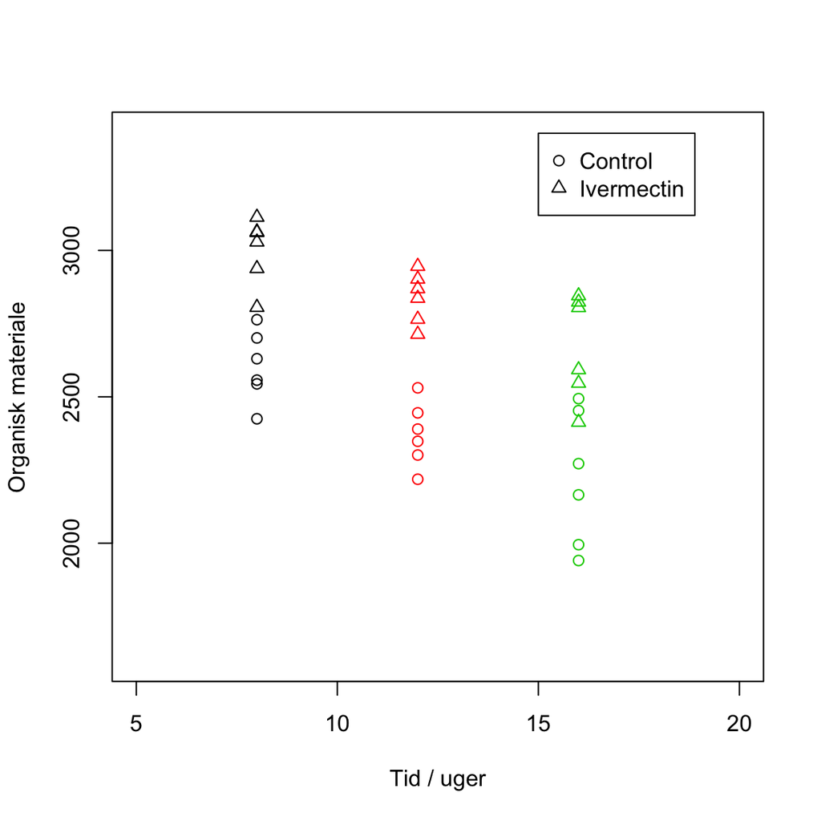

```r
plot(ex32$TIME, ex32$organic, col = factor(ex32$TIME), pch = as.numeric(ex32$TREAT)
     , xlab = "Tid / uger", ylab = "Organisk materiale"
     , xlim = c(5, 20), ylim = c(1600, 3400))
legend(15, 3400, legend = c("Control", "Ivermectin"), pch = 1:2)
```

### ggplot2 - kode

Ved brug af R pakken **ggplot2** (skal installeres på din computer!) kan man med lidt træning lave rigtig flot grafik.

```r
library(ggplot2)
ex32$TIMEFAC <- factor(ex32$TIME)
ggplot(data = ex32) + geom_point(aes(x = TIMEFAC,  y = organic, color = TIMEFAC, shape = TREAT), size = 2) +
  labs(x = "Tid / uger", y = "Organisk materiale")
```

[output not shown]

I meget grove træk opbygges figurer med **ggplot2** i lag

- `ggplot(data = ex32)` starter en figur og fortæller, at det er variablene i datasættet `ex32` der skal plottes på figuren
- `geom_point` fortæller, at den figur der skal laves er et såkaldt *scatterplot*
- argumenterne til `aes()` fortæller, hvordan variablene i datasættet `ex32` skal visuliseres på scatterplottet
  - **TIMEFAC** skal tegnes på x-aksen
  - **organic** (responsen) skal tegnes på y-aksen
  - punkterne skal farvekodes efter variablen **TIMEFAC**
  - punkterne skal have forskellig form for de to niveauer af **TREAT**
- argumentet `size` har betydning for størrelsen af punkterne på scatterplottet.